# GSD - week 8

2025-11-13

# Load the GSD package

```r
devtools::load_all(path = "../groupSequentialDesigns/")
```

```
## ℹ Loading groupSequentialDesigns
```

Contains:

1. `calc_bounds_of()`
2. `calc_bounds_pocock()`
3. `calc_bounds_triangular()`
4. `gsd_simulations()`

# Calculate staged power

Calculate the boundaries.

```r
pocock_bounds <- calc_bounds_pocock()
of_bounds <- calc_bounds_of()
tri_bounds <- calc_bounds_triangular()
```

Get values for ESS, VSS, and power.

First, generate $\delta$ vector.

```r
deltas <- seq(from = 0, to = 1, by = 0.001)
```

```r
gsd_simulations(upper_bounds = pocock_bounds$upper_bounds,
                         lower_bounds = pocock_bounds$lower_bounds,
                         alt_hypothesis = deltas[1],
                         n_patients = c(19.51241 * 1:3))$analysis_1["efficacy_alt"]
```

```
## efficacy_alt
##   0.02317511
```

## Pocock

```r
pk_analysis_1 <- vector(mode = "numeric", length = length(deltas))
pk_analysis_2 <- vector(mode = "numeric", length = length(deltas))
pk_analysis_3 <- vector(mode = "numeric", length = length(deltas))

for (i in 1:length(deltas)) {

  sim <- gsd_simulations(upper_bounds = pocock_bounds$upper_bounds,
                         lower_bounds = pocock_bounds$lower_bounds,
                         alt_hypothesis = deltas[i],
                         n_patients = c(19.51241 * 1:3))

  pk_analysis_1[i] <- sim$analysis_1["efficacy_alt"]
  pk_analysis_2[i] <- sim$analysis_2["efficacy_alt"]
  pk_analysis_3[i] <- sim$analysis_3["efficacy_alt"]
}
```

## O’Brien-Fleming

```r
of_analysis_1 <- vector(mode = "numeric", length = length(deltas))
of_analysis_2 <- vector(mode = "numeric", length = length(deltas))
of_analysis_3 <- vector(mode = "numeric", length = length(deltas))

for (i in 1:length(deltas)) {

  sim <- gsd_simulations(upper_bounds = of_bounds$upper_bounds,
                         lower_bounds = of_bounds$lower_bounds,
                         alt_hypothesis = deltas[i],
                         n_patients = c(16.93269 * 1:3))

  of_analysis_1[i] <- sim$analysis_1["efficacy_alt"]
  of_analysis_2[i] <- sim$analysis_2["efficacy_alt"]
  of_analysis_3[i] <- sim$analysis_3["efficacy_alt"]
}
```

## Triangular

```r
tri_analysis_1 <- vector(mode = "numeric", length = length(deltas))
tri_analysis_2 <- vector(mode = "numeric", length = length(deltas))
tri_analysis_3 <- vector(mode = "numeric", length = length(deltas))

for (i in 1:length(deltas)) {

  sim <- gsd_simulations(upper_bounds = tri_bounds$upper_bounds,
                         lower_bounds = tri_bounds$lower_bounds,
                         alt_hypothesis = deltas[i],
                         n_patients = c(20.43845 * 1:3))

  tri_analysis_1[i] <- sim$analysis_1["efficacy_alt"]
  tri_analysis_2[i] <- sim$analysis_2["efficacy_alt"]
  tri_analysis_3[i] <- sim$analysis_3["efficacy_alt"]
}
```

All of the above have a cumulative power at the end of the trial of approximately 80%. At each stage, power is cumulative sum of the probability of claiming efficacy under the alternative.

## Plots

### Stage 1

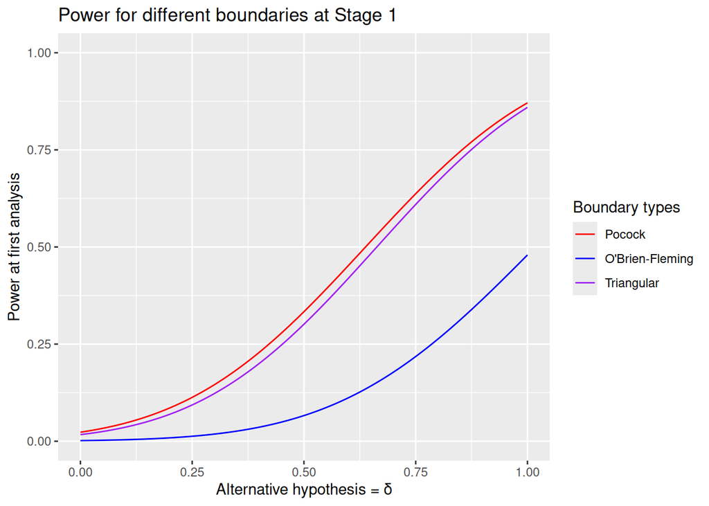

```r
ggplot() +
  geom_line(mapping = aes(x = deltas, y = pk_analysis_1, color = "Pocock")) +
  geom_line(mapping = aes(x = deltas, y = of_analysis_1, color = "O'Brien-Fleming")) +
  geom_line(mapping = aes(x = deltas, y = tri_analysis_1, color = "Triangular")) +
  ylim(c(0,1)) +
  scale_color_manual(name = "Boundary types",
                     breaks = c("Pocock", "O'Brien-Fleming", "Triangular"),
                     values = c("Pocock" = "red",
                                "O'Brien-Fleming" = "blue",
                                "Triangular" = "purple")) +
  labs(x = "Alternative hypothesis = \u03B4",
       y = "Power at first analysis",
       title = "Power for different boundaries at Stage 1")
```

### Stage 2

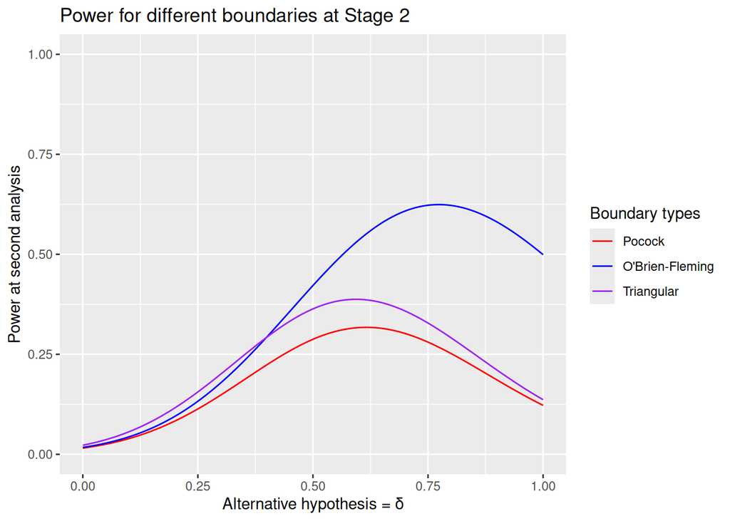

```r
ggplot() +
  geom_line(mapping = aes(x = deltas, y = pk_analysis_2, color = "Pocock")) +
  geom_line(mapping = aes(x = deltas, y = of_analysis_2, color = "O'Brien-Fleming")) +
  geom_line(mapping = aes(x = deltas, y = tri_analysis_2, color = "Triangular")) +
  ylim(c(0,1)) +
  scale_color_manual(name = "Boundary types",
                     breaks = c("Pocock", "O'Brien-Fleming", "Triangular"),
                     values = c("Pocock" = "red",
                                "O'Brien-Fleming" = "blue",
                                "Triangular" = "purple")) +
  labs(x = "Alternative hypothesis = \u03B4",
       y = "Power at second analysis",
       title = "Power for different boundaries at Stage 2")
```

### Stage 3

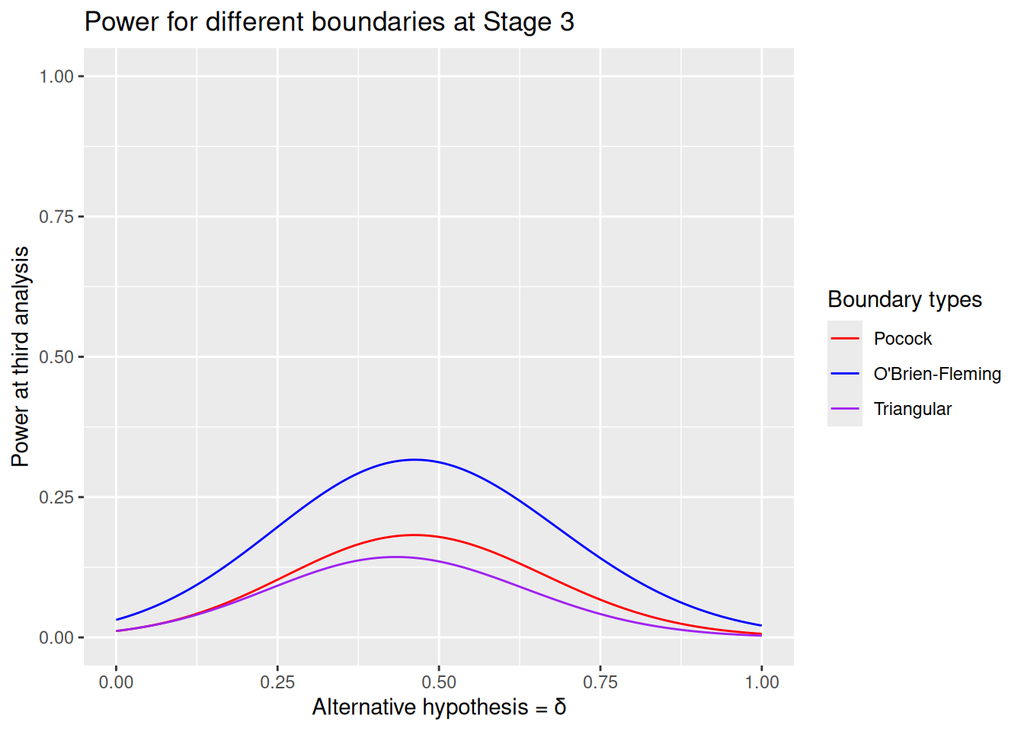

```r
ggplot() +
  geom_line(mapping = aes(x = deltas, y = pk_analysis_3, color = "Pocock")) +
  geom_line(mapping = aes(x = deltas, y = of_analysis_3, color = "O'Brien-Fleming")) +
  geom_line(mapping = aes(x = deltas, y = tri_analysis_3, color = "Triangular")) +
  ylim(c(0,1)) +
  scale_color_manual(name = "Boundary types",
                     breaks = c("Pocock", "O'Brien-Fleming", "Triangular"),
                     values = c("Pocock" = "red",
                                "O'Brien-Fleming" = "blue",
                                "Triangular" = "purple")) +
  labs(x = "Alternative hypothesis = \u03B4",
       y = "Power at third analysis",
       title = "Power for different boundaries at Stage 3")
```

## Cumulative sum plots

### Stage 1

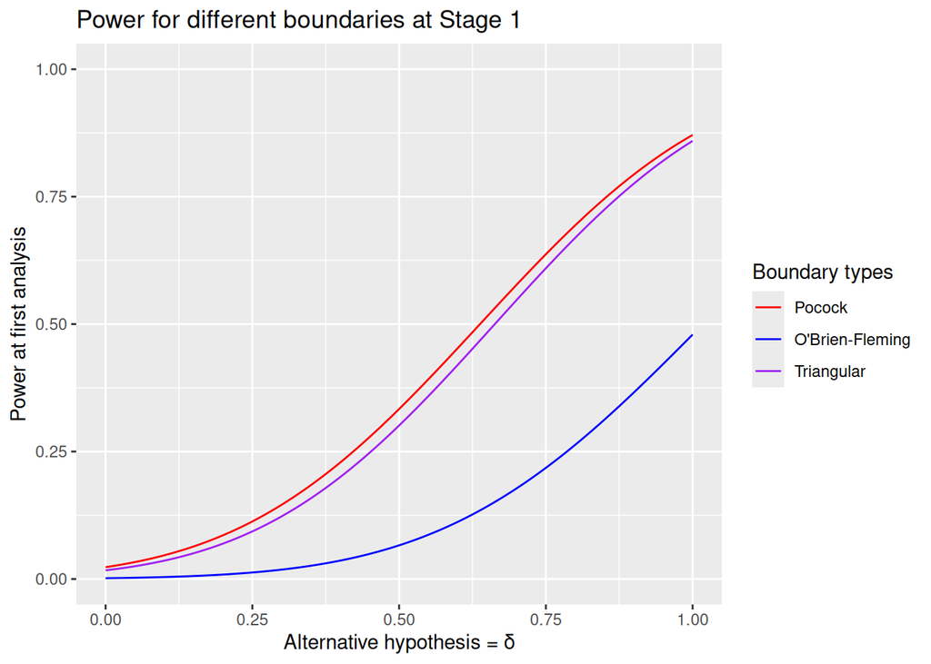

```r
ggplot() +
  geom_line(mapping = aes(x = deltas, y = pk_analysis_1, color = "Pocock")) +
  geom_line(mapping = aes(x = deltas, y = of_analysis_1, color = "O'Brien-Fleming")) +
  geom_line(mapping = aes(x = deltas, y = tri_analysis_1, color = "Triangular")) +
  ylim(c(0,1)) +
  scale_color_manual(name = "Boundary types",
                     breaks = c("Pocock", "O'Brien-Fleming", "Triangular"),
                     values = c("Pocock" = "red",
                                "O'Brien-Fleming" = "blue",
                                "Triangular" = "purple")) +
  labs(x = "Alternative hypothesis = \u03B4",
       y = "Power at first analysis",
       title = "Power for different boundaries at Stage 1")
```

### Stage 2

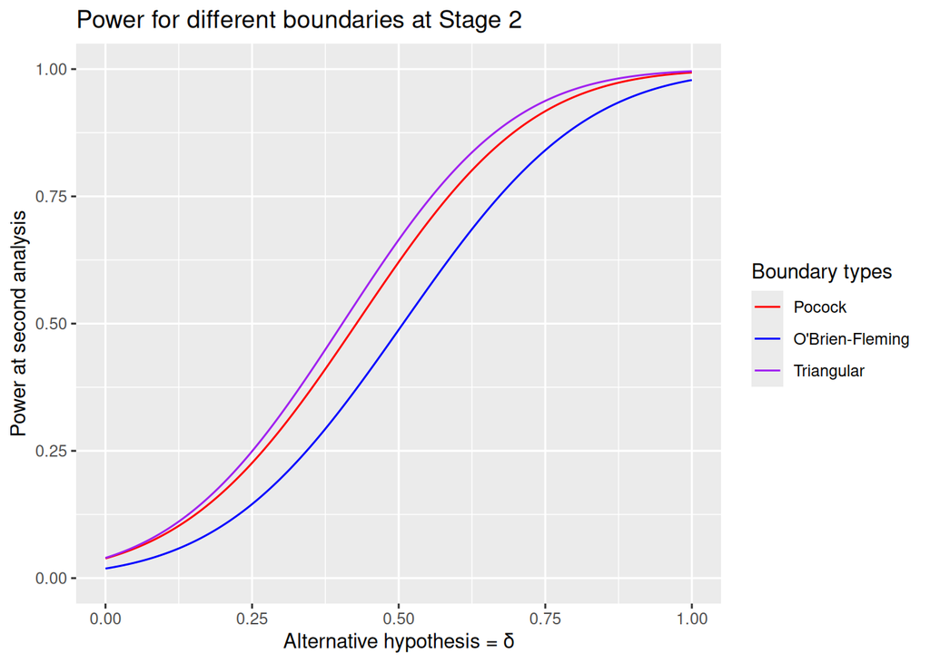

```r
ggplot() +
  geom_line(mapping = aes(x = deltas, y = pk_analysis_1+pk_analysis_2, color = "Pocock")) +
  geom_line(mapping = aes(x = deltas, y = of_analysis_1+of_analysis_2, color = "O'Brien-Fleming")) +
  geom_line(mapping = aes(x = deltas, y = tri_analysis_1+tri_analysis_2, color = "Triangular")) +
  ylim(c(0,1)) +
  scale_color_manual(name = "Boundary types",
                     breaks = c("Pocock", "O'Brien-Fleming", "Triangular"),
                     values = c("Pocock" = "red",
                                "O'Brien-Fleming" = "blue",
                                "Triangular" = "purple")) +
  labs(x = "Alternative hypothesis = \u03B4",
       y = "Power at second analysis",
       title = "Power for different boundaries at Stage 2")
```

### Stage 3

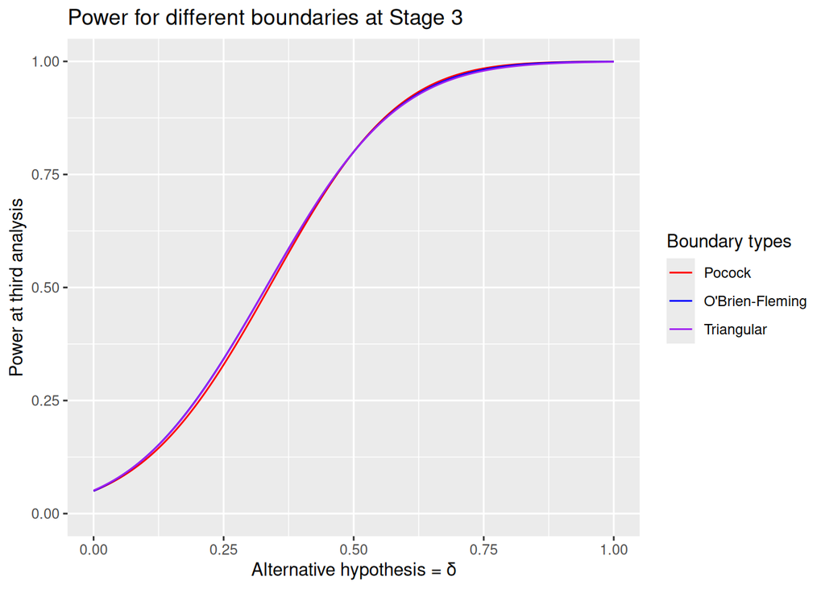

```r
ggplot() +
  geom_line(mapping = aes(x = deltas, y = pk_analysis_1+pk_analysis_2+pk_analysis_3, color = "Pocock")) +
  geom_line(mapping = aes(x = deltas, y = of_analysis_1+of_analysis_2+of_analysis_3, color = "O'Brien-Fleming")) +
  geom_line(mapping = aes(x = deltas, y = tri_analysis_1+tri_analysis_2+tri_analysis_3, color = "Triangular")) +
  ylim(c(0,1)) +
  scale_color_manual(name = "Boundary types",
                     breaks = c("Pocock", "O'Brien-Fleming", "Triangular"),
                     values = c("Pocock" = "red",
                                "O'Brien-Fleming" = "blue",
                                "Triangular" = "purple")) +
  labs(x = "Alternative hypothesis = \u03B4",
       y = "Power at third analysis",
       title = "Power for different boundaries at Stage 3")
```

# David’s Triangular test code

## 1. Define the Boundary Function

```r
get_boundaries <- function(alpha, delta, Imax, K) {
  # Information levels at each look k=1...K
  k <- 1:K
  I_k <- (k / K) * Imax

  # The correction factor for discrete monitoring (0.583 is the specific constant)
  correction <- 0.583 * sqrt(Imax / K)

  # Common intercept term (A)
  intercept <- (2 / delta) * log(1 / (2 * alpha))

  # Calculate Upper Boundary (dk)
  # Formula: (2/delta)*log(1/(2*alpha)) - 0.583*sqrt(Imax/K) + (delta/4)*I_k
  dk <- intercept - correction + (delta / 4) * I_k

  # Calculate Lower Boundary (ck)
  # Formula: -(2/delta)*log(1/(2*alpha)) + 0.583*sqrt(Imax/K) + (3*delta/4)*I_k
  ck <- -intercept + correction + (3 * delta / 4) * I_k

  return(list(k = k, I_k = I_k, lower = ck, upper = dk))
}
```

## 2. Simulation Function

```r
simulate_gst <- function(n_sim, alpha, delta, Imax, K, true_theta) {

  # Get boundaries
  bounds <- get_boundaries(alpha, delta, Imax, K)
  upper <- bounds$upper
  lower <- bounds$lower

  # Information increment per stage
  info_increment <- Imax / K

  # Initialize counters
  rejected <- 0
  accepted <- 0 # Accepted Null (futility)
  overrun  <- 0 # Reached max K without crossing (should be rare in Triangular designs)

  # Standard Error of the increment (sqrt of information increment)
  sd_increment <- sqrt(info_increment)
  # Mean of the increment (theta * information increment)
  mean_increment <- true_theta * info_increment

  # Run Simulation (Vectorized loop for efficiency)
  # We generate the full paths, then check stopping conditions

  # Generate all increments: matrix of size (n_sim x K)
  increments <- matrix(rnorm(n_sim * K, mean = mean_increment, sd = sd_increment),
                       nrow = n_sim, ncol = K)

  # Calculate cumulative score statistic Sk
  # t(apply(...)) is used because apply returns column-vectors
  Sk <- t(apply(increments, 1, cumsum))

  # Evaluate stopping criteria
  for (i in 1:n_sim) {
    path <- Sk[i, ]
    stopped <- FALSE

    for (stage in 1:K) {
      if (path[stage] >= upper[stage]) {
        rejected <- rejected + 1
        stopped <- TRUE
        break
      } else if (path[stage] <= lower[stage]) {
        accepted <- accepted + 1
        stopped <- TRUE
        break
      }
    }

    # Check if trial finished without crossing boundaries
    if (!stopped) {
      # In a closed triangular test, usually the boundaries meet.
      # If they haven't met by K and we haven't crossed, we need a convention.
      # Convention: If Sk > (upper+lower)/2, Reject. Otherwise Accept.
      # For this simulation, we simply track it as 'overrun' or failure to reject.
      overrun <- overrun + 1
    }
  }

  return(list(
    rate = rejected / n_sim,
    overrun_rate = overrun / n_sim,
    n_sim = n_sim
  ))
}
```

## 3. Execution and Visualization (using $\tilde{\delta}$)

```r
# Parameters
set.seed(123)

alpha_param <- alpha <- 0.05
delta_param <- 0.693147   # Effect size (e.g., log-hazard ratio or mean diff)

K <- 3

beta <- 0.3

delta_param <- 2*qnorm(1-alpha)*delta_param/(qnorm(1-alpha)+qnorm(1-beta))


Imax_param  <- (sqrt(4*0.583^2/K + 8*log(1/(2*alpha))) - 2*0.583/sqrt(K))^2/delta_param^2    # Max Information (depends on variance and N)

K_param     <- 3   # Number of looks
N_SIM       <- 10000

# Get Boundaries for plotting
b <- get_boundaries(alpha_param, delta_param, Imax_param, K_param)

# --- Run Simulation: Power (True Theta = Delta) ---
res_power <- simulate_gst(N_SIM, alpha_param, delta_param, Imax_param, K_param,
                          true_theta = 0.693147)

# --- Run Simulation: Type I Error (True Theta = 0) ---
res_type1 <- simulate_gst(N_SIM, alpha_param, delta_param, Imax_param, K_param,
                          true_theta = 0)

# 4. Print Results
cat("==========================================\n")
cat("Group Sequential Trial Simulation Results\n")
```

```
## Group Sequential Trial Simulation Results
```

```r
cat("==========================================\n")
cat(sprintf("Parameters: alpha=%.3f, delta=%.2f, Imax=%.1f, K=%d\n",
            alpha_param, delta_param, Imax_param, K_param))
```

```
## Parameters: alpha=0.050, delta=1.05, Imax=12.2, K=3
```

```r
cat("------------------------------------------\n")
cat(sprintf("Estimated Power (Theta = %.2f):     %.4f\n", delta_param, res_power$rate))
```

```
## Estimated Power (Theta = 1.05):     0.6895
```

```r
cat(sprintf("Estimated Type I Error (Theta = 0): %.4f\n", res_type1$rate))
```

```
## Estimated Type I Error (Theta = 0): 0.0518
```

```r
cat("==========================================\n")
b
```

```
## $k
## [1] 1 2 3
##
## $I_k
## [1]  4.065877  8.131754 12.197632
##
## $lower
## [1] 1.776357e-15 3.205440e+00 6.410881e+00
##
## $upper
## [1] 4.273920 5.342400 6.410881
```

## 3. Execution and Visualization (using $\delta$)

```r
# Parameters
set.seed(123)

alpha_param <- alpha <- 0.05
delta <- 0.693147   # Effect size (e.g., log-hazard ratio or mean diff)

K <- 3

beta <- 0.3

delta_param <- 2*qnorm(1-alpha)*delta/(qnorm(1-alpha)+qnorm(1-beta))


Imax_param  <- (sqrt(4*0.583^2/K + 8*log(1/(2*alpha))) - 2*0.583/sqrt(K))^2/delta_param^2    # Max Information (depends on variance and N)

K_param     <- 3   # Number of looks
N_SIM       <- 10000

# Get Boundaries for plotting
b <- get_boundaries(alpha_param, delta_param, Imax_param, K_param)

# --- Run Simulation: Power (True Theta = Delta) ---
res_power <- simulate_gst(N_SIM, alpha_param, delta, Imax_param, K_param,
                          true_theta = 0.693147)

# --- Run Simulation: Type I Error (True Theta = 0) ---
res_type1 <- simulate_gst(N_SIM, alpha_param, delta, Imax_param, K_param,
                          true_theta = 0)

# 4. Print Results
cat("==========================================\n")
cat("Group Sequential Trial Simulation Results\n")
```

```
## Group Sequential Trial Simulation Results
```

```r
cat("==========================================\n")
cat(sprintf("Parameters: alpha=%.3f, delta=%.2f, Imax=%.1f, K=%d\n",
            alpha_param, delta_param, Imax_param, K_param))
```

```
## Parameters: alpha=0.050, delta=1.05, Imax=12.2, K=3
```

```r
cat("------------------------------------------\n")
cat(sprintf("Estimated Power (Theta = %.2f):     %.4f\n", delta_param, res_power$rate))
```

```
## Estimated Power (Theta = 1.05):     0.6057
```

```r
cat(sprintf("Estimated Type I Error (Theta = 0): %.4f\n", res_type1$rate))
```

```
## Estimated Type I Error (Theta = 0): 0.0201
```

```r
cat("==========================================\n")
b
```

```
## $k
## [1] 1 2 3
##
## $I_k
## [1]  4.065877  8.131754 12.197632
##
## $lower
## [1] 1.776357e-15 3.205440e+00 6.410881e+00
##
## $upper
## [1] 4.273920 5.342400 6.410881
```

Note that when simulating under $\tilde{\delta}$ the values of $\alpha$ and $\beta$ are near the nominal values. However, when simulating under $\delta$, $\alpha$ and $\beta$ are not near the nominal values (see above parentheticals in code).

```r
dave_test <- calc_bounds_triangular(n_analyses = 5, alpha = 0.05, delta = 0.66)
dave_test
```

```
## $upper_bounds
## [1] 2.550487 2.104045 1.963366 1.912865 1.901021
##
## $lower_bounds
## [1] -0.8501624  0.3005778  0.9816830  1.4877843  1.9010210
##
## $info
## [1]  6.637063 13.274126 19.911189 26.548252 33.185315
```

```r
b$upper
```

```
## [1] 4.273920 5.342400 6.410881
```

```r
b$lower
```

```
## [1] 1.776357e-15 3.205440e+00 6.410881e+00
```

```r
gsd_simulations(n_analyses = 3, upper_bounds = b$upper, lower_bounds = b$lower,
                n_patients = c(100, 200, 300))
```

```
## $analysis_1
## futility_null efficacy_null  futility_alt  efficacy_alt
##  5.000000e-01  9.603282e-06  2.034760e-04  2.301398e-01
##
## $analysis_2
## futility_null efficacy_null  futility_alt  efficacy_alt
##  4.993210e-01  3.202765e-08  3.614703e-02  1.880933e-01
##
## $analysis_3
## futility_null efficacy_null  futility_alt  efficacy_alt
##  6.694254e-04  3.075781e-11  4.566471e-01  8.877459e-02
##
## $expected_sample_size
## [1] 231.5089
##
## $var_sample_size
## [1] 6764.627
##
## $alpha
## [1] 9.635341e-06
##
## $power
## [1] 0.5070077
```

# Mazin’s New Triangular bounds

```r
calc_bounds_triangular_new <- function(n_analyses = 3,
                                       alpha = 0.05,
                                       power = 0.7,
                                       delta = 0.693147) {

  beta <- 1-power

  delta_tilde <- (2 * qnorm(1-alpha) * delta) / (qnorm(1-alpha) + qnorm(1-beta))

  I_L_term1 <- (4 * (0.583^2)) / n_analyses
  I_L_term2 <- 8 * log(1/(2*alpha))
  I_L_term3 <- (2 * 0.583) / sqrt(n_analyses)

  # replace delta with delta_tilde
  I_L <- (sqrt(I_L_term1 + I_L_term2) - I_L_term3)^2 * (1 / delta_tilde)^2

  # replace delta with delta_tilde
  bounds_term1 <- (2/delta_tilde) * log(1/(2*alpha))

  # unchanged
  bounds_term2 <- 0.583 * sqrt(I_L / n_analyses)

  analysis_fracs <- (1:n_analyses / n_analyses)
  I_L_fracs <- I_L * analysis_fracs

  # replace delta with delta_tilde
  e_l <- (bounds_term1 - bounds_term2 + ((0.25*delta_tilde) * analysis_fracs * I_L )) / sqrt(I_L_fracs)

  # replace delta with delta_tilde
  f_l <- (-bounds_term1 + bounds_term2 + ((0.75*delta_tilde) * analysis_fracs * I_L )) / sqrt(I_L_fracs)

  # return delta_tilde as well
  return(list(upper_bounds = e_l,
              lower_bounds = f_l,
              delta_tilde = delta_tilde,
              info = I_L_fracs,
              sq_info = sqrt(I_L_fracs)))


}
```

```r
calc_bounds_triangular_new(power=0.9)
```

```
## $upper_bounds
## [1] 2.119577 1.873460 1.835608
##
## $lower_bounds
## [1] 6.530239e-16 1.124076e+00 1.835608e+00
##
## $delta_tilde
## [1] 0.7791986
##
## $info
## [1]  7.399499 14.798998 22.198497
##
## $sq_info
## [1] 2.720202 3.846947 4.711528
```

```r
calc_bounds_triangular_new(power=0.7)
```

```
## $upper_bounds
## [1] 2.119577 1.873460 1.835608
##
## $lower_bounds
## [1] 6.607153e-16 1.124076e+00 1.835608e+00
##
## $delta_tilde
## [1] 1.051168
##
## $info
## [1]  4.065877  8.131754 12.197632
##
## $sq_info
## [1] 2.016402 2.851623 3.492511
```

Note above that regardless of power selected, the triangular bounds are the same on the $Z$ score scale. However, there are large differences in the square root of the information ($\sqrt{I_l} = \texttt{sq_info}$) and the score bounds are indeed different. The function below calculates under the score scale.

```r
calc_bounds_triangular_new_score <- function(n_analyses = 3,
                                       alpha = 0.05,
                                       power = 0.7,
                                       delta = 0.693147) {

  beta <- 1-power

  delta_tilde <- (2 * qnorm(1-alpha) * delta) / (qnorm(1-alpha) + qnorm(1-beta))

  I_L_term1 <- (4 * (0.583^2)) / n_analyses
  I_L_term2 <- 8 * log(1/(2*alpha))
  I_L_term3 <- (2 * 0.583) / sqrt(n_analyses)

  # replace delta with delta_tilde
  I_L <- (sqrt(I_L_term1 + I_L_term2) - I_L_term3)^2 * (1 / delta_tilde)^2

  # replace delta with delta_tilde
  bounds_term1 <- (2/delta_tilde) * log(1/(2*alpha))

  # unchanged
  bounds_term2 <- 0.583 * sqrt(I_L / n_analyses)

  analysis_fracs <- (1:n_analyses / n_analyses)
  I_L_fracs <- I_L * analysis_fracs

  # replace delta with delta_tilde
  # we are commenting out the standardization sqrt(I_L_fracs)
  e_l <- (bounds_term1 - bounds_term2 + ((0.25*delta_tilde) * analysis_fracs * I_L )) #/ sqrt(I_L_fracs)

  # replace delta with delta_tilde
  # we are commenting out the standardization sqrt(I_L_fracs)
  f_l <- (-bounds_term1 + bounds_term2 + ((0.75*delta_tilde) * analysis_fracs * I_L )) #/ sqrt(I_L_fracs)

  # return delta_tilde as well
  return(list(upper_bounds = e_l,
              lower_bounds = f_l,
              delta_tilde = delta_tilde,
              info = I_L_fracs,
              sq_info = sqrt(I_L_fracs)))


}
```

```r
calc_bounds_triangular_new_score(power=0.9)
```

```
## $upper_bounds
## [1] 5.765679 7.207099 8.648518
##
## $lower_bounds
## [1] 1.776357e-15 4.324259e+00 8.648518e+00
##
## $delta_tilde
## [1] 0.7791986
##
## $info
## [1]  7.399499 14.798998 22.198497
##
## $sq_info
## [1] 2.720202 3.846947 4.711528
```

```r
calc_bounds_triangular_new_score(power=0.7)
```

```
## $upper_bounds
## [1] 4.273920 5.342400 6.410881
##
## $lower_bounds
## [1] 1.332268e-15 3.205440e+00 6.410881e+00
##
## $delta_tilde
## [1] 1.051168
##
## $info
## [1]  4.065877  8.131754 12.197632
##
## $sq_info
## [1] 2.016402 2.851623 3.492511
```

Note the large difference in the bounds, the information, the square root of the information given the change in the power.

```r
gsd_simulations(n_analyses = 3, upper_bounds = calc_bounds_triangular_new()$upper_bounds,
                lower_bounds = calc_bounds_triangular_new()$lower_bounds,
                n_patients = c(10,20,30), null_hypothesis = 0, alt_hypothesis = 0.7791986)
```

```
## $analysis_1
## futility_null efficacy_null  futility_alt  efficacy_alt
##    0.50000000    0.01702085    0.04072439    0.35299895
##
## $analysis_2
## futility_null efficacy_null  futility_alt  efficacy_alt
##    0.37463706    0.02267064    0.06484552    0.38093388
##
## $analysis_3
## futility_null efficacy_null  futility_alt  efficacy_alt
##    0.07417764    0.01149562    0.03818251    0.12231564
##
## $expected_sample_size
## [1] 17.66777
##
## $var_sample_size
## [1] 49.98248
##
## $alpha
## [1] 0.05118711
##
## $power
## [1] 0.8562485
```

The difference between my code and David’s is:  
1. the mean and standard deviation calculated in my code is using `n_patients` and `variance` while David’s code is using `mean = true_theta * info_increment` and standard deviation is `sd = sqrt(info_increment)`.  
2. the boundaries and simulation is occurring on the score scale for David’s code while it’s occurring on the standard Z scale in mine.

Results on the score scale for my code are (and were) correct.